# Understanding Female Labor Force Participation Rate (LFPR)

12/4/2019

## Background and Problem Statement

Benefits:

- Women empowerment and bargaining power
- Domestic violence goes down when wage gap narrows
- Impact on children’s educational outcomes
- If male and female LFPR were equal by 2025, the annual global GDP would increase by 26%

Problem:

- Female LFPR and GDP per capita:U-shaped
- Some countries: female LFPR is decreasing despite economic growth

## Data

World Bank Database - the “wbstats” R-package

Data from Web Scraping

- safety ranking
- minimum wage law
- religion
- etc.

## Current Variables

Dependent Variable: Female LFPR (interval-based outcome)

Independent Variables(8):

- GDP per capita
- % literacy rate among adult female
- fertility rate (births per woman)
- time spent on unpaid domestic and care work for female (% of 24 hour day)
- compulsory education (years)
- % government expenditure on education
- % female aged 25+ completed at least lower secondary education
- % female aged 25+ completed at least Bachelor’s or equivalent

## Methods and Approaches

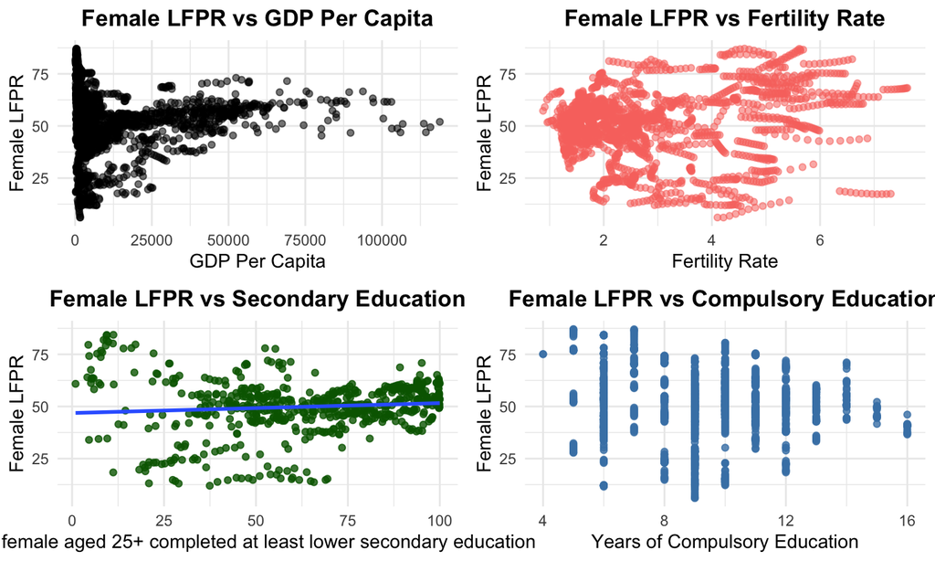

## Methods and Approaches

General: Exploratory Data Analysis

Supervised Learning (regression):

## Analysis

```
## Observations: 2,057
## Variables: 12
## $ country         <chr> "Afghanistan", "Afghanistan", "Afghanistan", "Af…
## $ ccode           <chr> "AFG", "AFG", "AFG", "AFG", "AFG", "AFG", "AFG",…
## $ year            <dbl> 2005, 2006, 2007, 2008, 2009, 2010, 2011, 2012, …
## $ f_lfpr          <dbl> 44.025, 43.597, 43.192, 42.873, 42.709, 42.735, …
## $ gdp_pcap        <dbl> 242.0314, 263.7337, 359.6935, 364.6605, 438.0760…
## $ f_literacy_rate <dbl> NA, NA, NA, NA, NA, NA, 17.61206, NA, NA, NA, NA…
## $ com_edu         <dbl> 6, 6, 6, 9, 9, 9, 9, 9, 9, 9, 9, 4, 4, 6, 6, 6, …
## $ f_lower_sec_edu <dbl> NA, NA, NA, NA, NA, NA, NA, NA, NA, NA, NA, NA, …
## $ f_ba_edu        <dbl> NA, NA, NA, NA, NA, NA, NA, NA, NA, NA, NA, NA, …
## $ gov_exp_edu     <dbl> NA, NA, NA, NA, NA, 17.06756, 16.04843, 10.35680…
## $ f_ptime_chores  <dbl> NA, NA, NA, NA, NA, NA, NA, NA, NA, NA, NA, NA, …
## $ fertility_rate  <dbl> 6.875, 6.722, 6.555, 6.373, 6.180, 5.977, 5.770,…
```

Unit of Analysis: country-year

Problem: lots of missing values

Solution:

- removed all obs with no info on female LFPR
- imputed all missing values for every independent variable

## Analysis

```r
#Reprocess the data
train_data1 <- train_data %>% select(-ccode,-country)

my_recipe <- recipe(f_lfpr~., data=train_data1) %>%
  step_knnimpute(all_predictors()) %>%
  step_range(all_numeric()) %>%
  prep()

train_data2 <- bake(my_recipe, train_data)
test_data2 <- bake(my_recipe, test_data)
```

```r
#Set cross-validation
set.seed(5678)
folds <- createFolds(train_data2$f_lfpr,k=5)
sapply(folds,length)
```

```
## Fold1 Fold2 Fold3 Fold4 Fold5
##   412   410   411   412   412
```

```r
cross_val <- trainControl(method = "cv", index = folds)
```

## Analysis

```r
#K-nearest Neighbors(KNN)
knn_tune = expand.grid(k=c(1,5,10,50))

model_knn <- train(f_lfpr~.,data = train_data2, method="knn",
                   metric="RMSE",trControl=cross_val,
                   tuneGrid=knn_tune)
```

```r
#Random Forest(ranger)

model_rf <- train(f_lfpr~., data=train_data2,method="ranger",
                  metric="RMSE", trControl=cross_val)
```

## Results

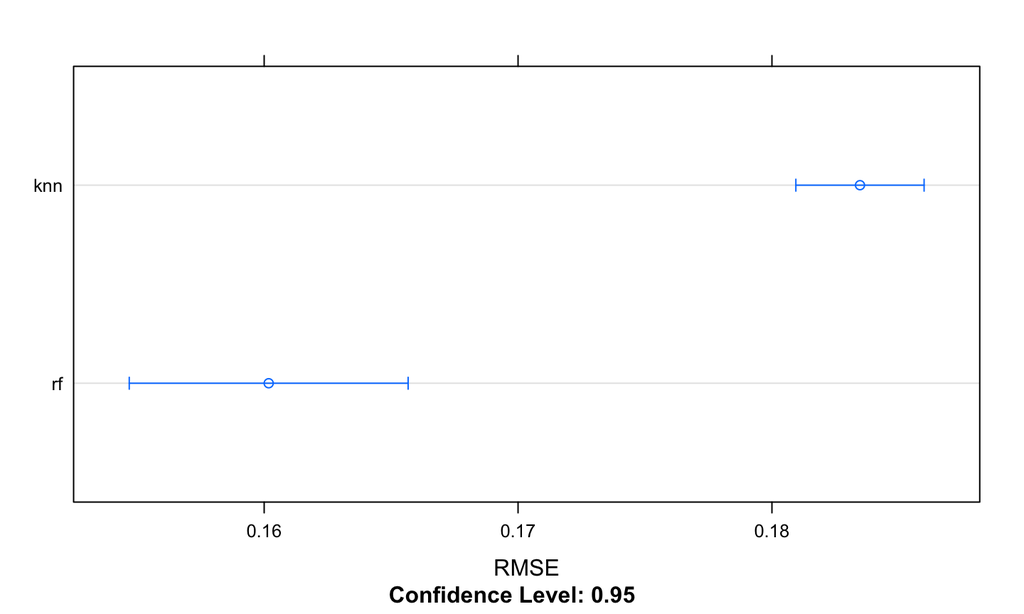

## Results

```r
#Test the out-of-sample predictive performance
prediction <-predict(model_knn, newdata = test_data2)
rmse = sqrt(sum((test_data2$f_lfpr - prediction)^2/nrow(test_data2)))
rmse
```

```
## [1] 0.1778308
```

## Lessons Learned and Next Steps

Lessons Learned:

- Low RMSE (good prediction): indepedent variables capture the info related to education, economic development and demographic indicators
- Probably not the whole story: other factors that affect female LFPR

Next Steps:

- Obtain more data
- Repeat EDA to understand the data better
- Estimate the female LFPR at the micro level